# Rejection

Jesús Cifuentes

02/04/2015

Al integrar utilizando el método del rechazo invocamos un total de 2000 números al azar entre los rangos mínimos y máximos de nuestra función, luego contamos cuantos de estos números caen por debajo de nuestra gráfica y la razón entre estos y el número total de puntos será la misma razon entre el área que deseamos y el área total donde ubicamos los puntos. A continuación se muestra el gráfico de la función $(cos(50x) +sin(20x))^2$ La cual vamos a integrar entre $0$ y $1$ con el método descrito. El resultado se mostrará después de la siguiente gráfica

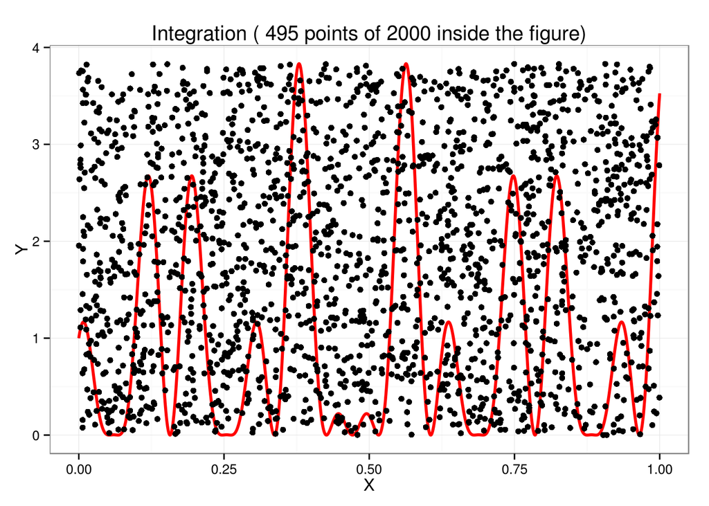

```
## [1] 0.948551
```

Mientras que si comparamos con la función integrate, obtenemos:

```
## 0.9652009 with absolute error < 1.9e-10
```

Como se puede ver los resultados son bastante cercanos, sin embargo, ya que solo estamos usando 2000 números aleatorios, varía bastante cada vez que se corre el programa. Una forma de mejorarlo sería utilizando más números aleatorios(lo cual no se realizó gráficamente ya que no se visualizaría bien la gráfica). Sin embargo este resultado más exacto (realizado con 10000 puntos) se muestra a continuación:

```
## [1] 0.9722781
```

Ahora realizamos la integral desde $2$ hasta infinito de la función $\frac{1}{\pi(1+x^2)}$. En este caso la gráfica es simplemente una muestra de la ubicación de los puntos, pero el modo de encontrar la verdadera integral es un poco más profundo. El resultado se muestra después de la gráfica.

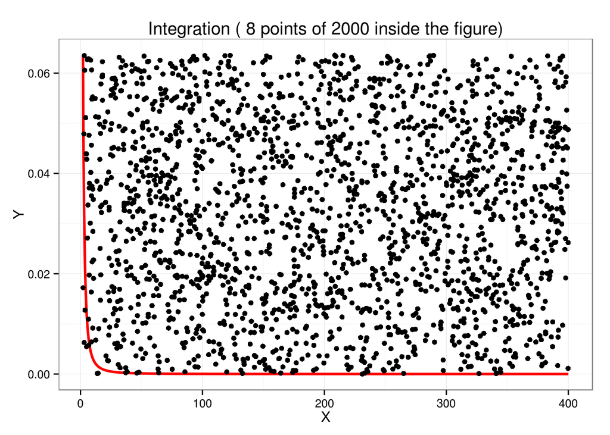

```
## [1] 0.1516055
```

Comparando nuestro resultado con el de la función integrate(que se encuentra a continuación), vemos que es bastante cercano pero todavía falta presición. El método utilizado fue básicamente integrar de a intervalos utilizando la función creada de (0-100), (100-200) , (200-300) … hasta que los términos añadidos sean obsoletos.

```
## 0.1475836 with absolute error < 1.3e-10
```